# survival_analysis_python_google_colab

[figure not shown]

Survival analysis models the probability that something "survives" (does NOT experience a specific event) beyond a certain time.

**analysis** This analysis looks at employee churn data (synthetic data from Kaggle) in order to identify the factors with the highest impact on time-to-churn.

**result** In order, the most impactful covariates were: having been recently promoted, having high satisfaction, having filed a complaint, having a high salary, being in the management or procurement departments, and having a relatively high number of projects.

**recommendation** In order to reduce employee churn, I recommend to the company leaders that they prioritize: promotions when appropriate, industry-competitive salaries (and raises), surveys to understand satisfaction drivers, survey questions also specifically for mgmt. & procurement, and having check-ins to offer employees more projects if they are interested. Additionally, I recommend they investigate cases where complaints were filed to understand pattern of it improving retention, as complaints would obviously not be a goal

[figure not shown]

## Install Packages

```python
!pip install lifelines
```

## Load Libraries

```python
import pandas as pd
import numpy as np
import seaborn as sns
import matplotlib.pyplot as plt
from lifelines import KaplanMeierFitter, CoxPHFitter
from lifelines import WeibullFitter, LogNormalFitter, LogLogisticFitter, ExponentialFitter, GeneralizedGammaFitter
from lifelines import WeibullAFTFitter, LogNormalAFTFitter, LogLogisticAFTFitter, GeneralizedGammaRegressionFitter
from lifelines.utils import median_survival_times
from sklearn.model_selection import KFold
from lifelines.calibration import survival_probability_calibration
from lifelines import exceptions
import contextlib
import io
import math
import warnings
```

Create custom color palette:

```python
custom_palette = [
    '#dfbefb',
    '#C49C94',
    '#dfd4c9',
    '#FAC287',
    '#cb95f9',
    '#B3B3F2',
    '#895b3a',
    '#8383F7',
    '#C2C8FF',
    '#e7dbf3',
    '#CACACC',
    '#C0F0EF',
    '#101827',
    '#1bc2bb'
]
```

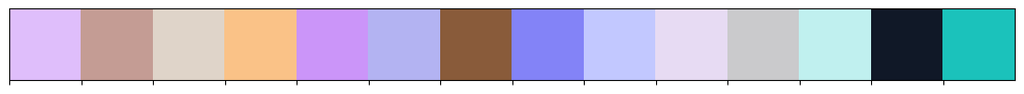

```python
sns.palplot(custom_palette)
plt.show()
```

[figure not shown]

```python
!wget "https://raw.githubusercontent.com/lindsayalexandra14/ds_portfolio/main/1_projects/machine_learning/time_series_and_survival/employee_churn/employee_churn.csv"
```

```
--2025-12-12 23:56:40--  https://raw.githubusercontent.com/lindsayalexandra14/ds_portfolio/main/1_projects/machine_learning/time_series_and_survival/employee_churn/employee_churn.csv
Resolving raw.githubusercontent.com (raw.githubusercontent.com)... 185.199.109.133, 185.199.111.133, 185.199.108.133, ...
Connecting to raw.githubusercontent.com (raw.githubusercontent.com)|185.199.109.133|:443... connected.
HTTP request sent, awaiting response... 200 OK
Length: 775551 (757K) [text/plain]
Saving to: ‘employee_churn.csv.3’

employee_churn.csv. 100%[===================>] 757.37K  --.-KB/s    in 0.1s

2025-12-12 23:56:40 (5.33 MB/s) - ‘employee_churn.csv.3’ saved [775551/775551]
```

```python
df = pd.read_csv("employee_churn.csv")
```

[figure not shown]

The data have n=14,249 employees and 10 variables:

```python
df.shape
```

```
(14249, 10)
```

```python
df.head()
```

|  | avg_monthly_hrs | department | filed_complaint | last_evaluation | n_projects | recently_promoted | salary | satisfaction | status | tenure |
| --- | --- | --- | --- | --- | --- | --- | --- | --- | --- | --- |
| 0 | 221 | engineering | NaN | 0.932868 | 4 | NaN | low | 0.829896 | Left | 5.0 |
| 1 | 232 | support | NaN | NaN | 3 | NaN | low | 0.834544 | Employed | 2.0 |
| 2 | 184 | sales | NaN | 0.788830 | 3 | NaN | medium | 0.834988 | Employed | 3.0 |
| 3 | 206 | sales | NaN | 0.575688 | 4 | NaN | low | 0.424764 | Employed | 2.0 |
| 4 | 249 | sales | NaN | 0.845217 | 3 | NaN | low | 0.779043 | Employed | 3.0 |

The data is right-censored, meaning the event has not happened yet for some subjects.

```python
df.info()
```

```
<class 'pandas.core.frame.DataFrame'>
RangeIndex: 14249 entries, 0 to 14248
Data columns (total 10 columns):
 #   Column             Non-Null Count  Dtype
---  ------             --------------  -----
 0   avg_monthly_hrs    14249 non-null  int64
 1   department         13540 non-null  object
 2   filed_complaint    2058 non-null   float64
 3   last_evaluation    12717 non-null  float64
 4   n_projects         14249 non-null  int64
 5   recently_promoted  300 non-null    float64
 6   salary             14249 non-null  object
 7   satisfaction       14068 non-null  float64
 8   status             14249 non-null  object
 9   tenure             14068 non-null  float64
dtypes: float64(5), int64(2), object(3)
memory usage: 1.1+ MB
```

Variable definitions:

```python
variables = {
    "avg_monthly_hours": "average monthly hours worked",
    "filed_complaint": '"1" for filed a work complaint (ever)',
    "last_evaluation": 'undefined - to be removed',
    "n_projects": "number of projects completed in past year",
    "recently_promoted": '"1" for promoted in past year',
    "satisfaction": "0-100, 100 for very satisfied",
    "tenure": "years at company"
}

for variable, definition in variables.items():
    print(f"{variable}: {definition}")
```

```
avg_monthly_hours: average monthly hours worked
filed_complaint: "1" for filed a work complaint (ever)
last_evaluation: undefined - to be removed
n_projects: number of projects completed in past year
recently_promoted: "1" for promoted in past year
satisfaction: 0-100, 100 for very satisfied
tenure: years at company
```

[figure not shown]

Explore missing values:

```python
missing_df = pd.DataFrame({
    'Missing Count': df.isnull().sum(),
    'Missing %': (df.isnull().sum() / len(df)) * 100
})
missing_df[missing_df['Missing Count'] > 0].sort_values('Missing %', ascending=False)
```

|  | Missing Count | Missing % |
| --- | --- | --- |
| recently_promoted | 13949 | 97.894589 |
| filed_complaint | 12191 | 85.556881 |
| last_evaluation | 1532 | 10.751632 |
| department | 709 | 4.975788 |
| satisfaction | 181 | 1.270265 |
| tenure | 181 | 1.270265 |

```python
df["recently_promoted"].unique()
```

```
array([nan,  1.])
```

```python
df["filed_complaint"].unique()
```

```
array([nan,  1.])
```

Fill 0 for recently_promoted and filed_complaint (assuming those are "No" responses).

```python
df["recently_promoted"] = df["recently_promoted"].fillna(0)
```

```python
df["filed_complaint"] = df["filed_complaint"].fillna(0)
```

Remove observations with null for department, satisfaction and tenure as there are enough samples with complete data.

```python
df = df.dropna(subset=["department", "satisfaction", "tenure"])
```

Remove last_evaluation as the metric is unclear.

```python
df = df.drop("last_evaluation", axis=1)
```

There are now 13,359 complete observations:

```python
df.info()
```

```
<class 'pandas.core.frame.DataFrame'>
Index: 13359 entries, 0 to 14247
Data columns (total 9 columns):
 #   Column             Non-Null Count  Dtype
---  ------             --------------  -----
 0   avg_monthly_hrs    13359 non-null  int64
 1   department         13359 non-null  object
 2   filed_complaint    13359 non-null  float64
 3   n_projects         13359 non-null  int64
 4   recently_promoted  13359 non-null  float64
 5   salary             13359 non-null  object
 6   satisfaction       13359 non-null  float64
 7   status             13359 non-null  object
 8   tenure             13359 non-null  float64
dtypes: float64(4), int64(2), object(3)
memory usage: 1.0+ MB
```

Change "status" to "churn" with 1 or 0:

```python
df["churn"] = np.where(df["status"] == "Employed", 0, 1)
```

```python
df.drop("status", axis=1, inplace=True)
```

Change "tenure" to indicate time (years):

```python
df.rename(columns={"tenure": "tenure_years"}, inplace=True)
```

```python
df.head()
```

|  | avg_monthly_hrs | department | filed_complaint | n_projects | recently_promoted | salary | satisfaction | tenure_years | churn |
| --- | --- | --- | --- | --- | --- | --- | --- | --- | --- |
| 0 | 221 | engineering | 0.0 | 4 | 0.0 | low | 0.829896 | 5.0 | 1 |
| 1 | 232 | support | 0.0 | 3 | 0.0 | low | 0.834544 | 2.0 | 0 |
| 2 | 184 | sales | 0.0 | 3 | 0.0 | medium | 0.834988 | 3.0 | 0 |
| 3 | 206 | sales | 0.0 | 4 | 0.0 | low | 0.424764 | 2.0 | 0 |
| 4 | 249 | sales | 0.0 | 3 | 0.0 | low | 0.779043 | 3.0 | 0 |

[figure not shown]

View summary statistics:

- Employees worked 200 hours/month on average (~47 hrs / week)
- 14.5% filed a work complaint (ever)
- Completed average of 3.8 projects in the past year
- 2% promoted in the past year
- 62% average satisfaction rate
- Average tenure of 3.5 years
- 24% employee churn rate

```python
df.describe()
```

|  | avg_monthly_hrs | filed_complaint | n_projects | recently_promoted | satisfaction | tenure_years | churn |
| --- | --- | --- | --- | --- | --- | --- | --- |
| count | 13359.000000 | 13359.000000 | 13359.000000 | 13359.000000 | 13359.000000 | 13359.000000 | 13359.000000 |
| mean | 201.203159 | 0.145071 | 3.807845 | 0.021334 | 0.622194 | 3.504155 | 0.236620 |
| std | 49.930370 | 0.352185 | 1.235721 | 0.144500 | 0.250476 | 1.473922 | 0.425023 |
| min | 96.000000 | 0.000000 | 2.000000 | 0.000000 | 0.040058 | 2.000000 | 0.000000 |
| 25% | 156.000000 | 0.000000 | 3.000000 | 0.000000 | 0.451782 | 3.000000 | 0.000000 |
| 50% | 200.000000 | 0.000000 | 4.000000 | 0.000000 | 0.654061 | 3.000000 | 0.000000 |
| 75% | 245.000000 | 0.000000 | 5.000000 | 0.000000 | 0.825668 | 4.000000 | 0.000000 |
| max | 310.000000 | 1.000000 | 7.000000 | 1.000000 | 1.000000 | 10.000000 | 1.000000 |

There are 3,161 employees in the data who have churned:

```python
df['churn'].sum()
```

```
np.int64(3161)
```

View outliers:

There are only outliers for tenure_years, and removing them would bias the data, so I will leave them in. They are reasonable/valid observations and their information is informative for churn behavior. It is reasonable for a group of employees to have stayed for 6-10 years, and there is a meaningful amount of them:

```python
numeric_columns = ['avg_monthly_hrs', 'n_projects','tenure_years']

for col in numeric_columns:
  Q1 = df[col].quantile(0.25)
  Q3 = df[col].quantile(0.75)
  IQR = Q3 - Q1

  lower_bound = Q1 - 1.5 * IQR
  upper_bound = Q3 + 1.5 * IQR

  outliers = df[(df[col] < lower_bound) | (df[col] > upper_bound)]
  print(col,"outliers:", len(outliers))
  print(col, "outlier values:", np.sort(outliers[col].unique()))
```

```
avg_monthly_hrs outliers: 0
avg_monthly_hrs outlier values: []
n_projects outliers: 0
n_projects outlier values: []
tenure_years outliers: 1154
tenure_years outlier values: [ 6.  7.  8. 10.]
```

Visualize tenure distribution:

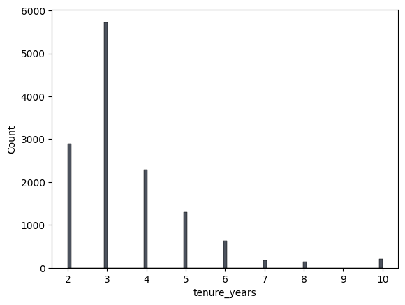

```python
sns.histplot(df["tenure_years"], color="#101827")
plt.show()
```

Churn vs. not comparisons (average & distribution):

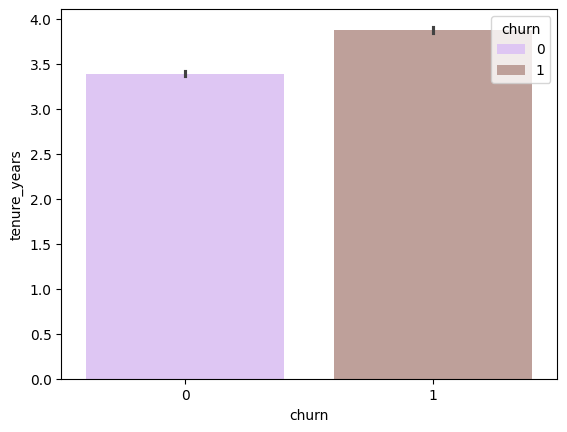

```python
palette_subset = custom_palette[:2]

sns.barplot(
    x='churn',
    y='tenure_years',
    data=df,
    hue='churn',
    palette=palette_subset
)

plt.show()
```

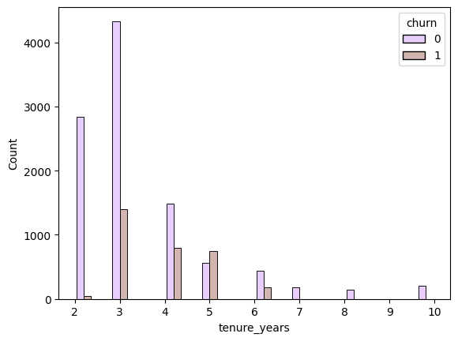

```python
palette_subset = custom_palette[:2]

sns.histplot(
    data=df,
    x="tenure_years",
    hue="churn",
    palette=palette_subset,
    bins=20,
    multiple="dodge",
    shrink=0.8
)

plt.show()
```

```python
print(f"Average tenure: {df['tenure_years'].mean():.2f} years")
```

```
Average tenure: 3.50 years
```

```python
print(f"Average tenure for churned: {df.loc[df["churn"] == 1, "tenure_years"].mean():.2f} years")
```

```
Average tenure for churned: 3.88 years
```

```python
print(f"Average tenure for non-churned: {df.loc[df["churn"] == 0, "tenure_years"].mean():.2f} years")
```

```
Average tenure for non-churned: 3.39 years
```

Merge duplicate IT and information technology departments:

```python
df['department'] = df['department'].replace({'information_technology': 'IT'})
```

Calculate and view churn by department:

The highest churn rates come from Finance & Engineering, whereas the lowest come from Management and Procurement:

```python
dept_churn = df.groupby("department")["churn"].mean().reset_index()
dept_churn["churn"] = dept_churn["churn"].round(2)
```

```python
df['department'].unique()
```

```
array(['engineering', 'support', 'sales', 'IT', 'product', 'marketing',
       'procurement', 'finance', 'management', 'admin'], dtype=object)
```

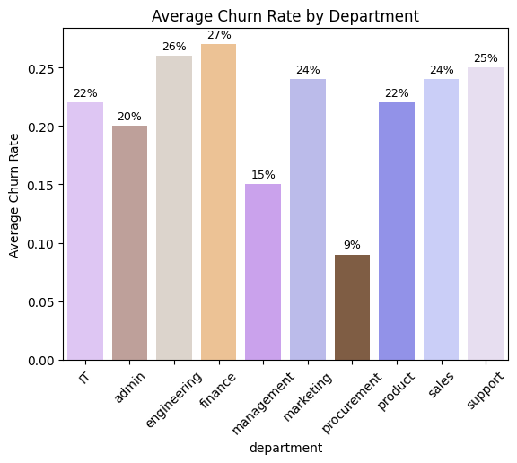

```python
palette_subset = custom_palette[:10]

ax=sns.barplot(
    data=dept_churn,
    x="department",
    y="churn",
    palette=palette_subset,
    hue="department",
    legend=False
)

for p in ax.patches:
    height = p.get_height()
    ax.annotate(
        f"{height*100:.0f}%",
        (p.get_x() + p.get_width() / 2, height),
        ha="center",
        va="bottom",
        fontsize=9,
        xytext=(0, 3),
        textcoords="offset points"
    )

plt.xticks(rotation=45)
plt.ylabel("Average Churn Rate")
plt.title("Average Churn Rate by Department")
plt.show()
```

```python
df.head()
```

|  | avg_monthly_hrs | department | filed_complaint | n_projects | recently_promoted | salary | satisfaction | tenure_years | churn |
| --- | --- | --- | --- | --- | --- | --- | --- | --- | --- |
| 0 | 221 | engineering | 0.0 | 4 | 0.0 | low | 0.829896 | 5.0 | 1 |
| 1 | 232 | support | 0.0 | 3 | 0.0 | low | 0.834544 | 2.0 | 0 |
| 2 | 184 | sales | 0.0 | 3 | 0.0 | medium | 0.834988 | 3.0 | 0 |
| 3 | 206 | sales | 0.0 | 4 | 0.0 | low | 0.424764 | 2.0 | 0 |
| 4 | 249 | sales | 0.0 | 3 | 0.0 | low | 0.779043 | 3.0 | 0 |

Create bins for satisfaction to separate between low, medium, and high salary values:

```python
bins = [0.0, 0.33, 0.66, 1.0]
labels = ['low', 'medium', 'high']

df['satisfaction'] = pd.cut(df['satisfaction'], bins=bins, labels=labels, include_lowest=True)
```

```python
print(df['satisfaction'].head())
```

```
0      high
1      high
2      high
3    medium
4      high
Name: satisfaction, dtype: category
Categories (3, object): ['low' < 'medium' < 'high']
```

Get dummy variables for department:

```python
df = pd.get_dummies(df,columns=['department'], drop_first=False)
```

Drop "department_support" manually because it has a churn rate close to the average, making it a better reference variable:

```python
df = df.drop(columns=['department_support'])
```

Get dummies for rest of data:

```python
df = pd.get_dummies(df, drop_first=True)

df.rename(columns={'filed_complaint_Yes':'Filed Complaint'}, inplace=True)
df.rename(columns={'recently_promoted_Yes':'Recently Promoted'}, inplace=True)
```

[figure not shown]

The Kaplan-Meier curve shows the actual distribution of the data through a "KM estimate". This estimate measures the survival probability for a random individual beyond time t. It adjusts for censoring by only measuring subjects "at risk" at each time. To do this it removes them from the "at risk" group after their censoring time, so they contribute until their censoring time and not after.

The "conditional" survival probabilities are calculated as:(1−di/ni): di is the # of (churn) events at ti, ni is the number of employees at risk at that time (having no event or censoring yet).

To calculate the "cumulative" survival probability at time t, the product of these "conditional" survival probabilities is taken up to time t.

Plot Kaplan-Meier Curve:

The "churn percentages" (censoring-adjusted) are also shown in green to show the drop-off, which is the highest with 30% at 5 years:

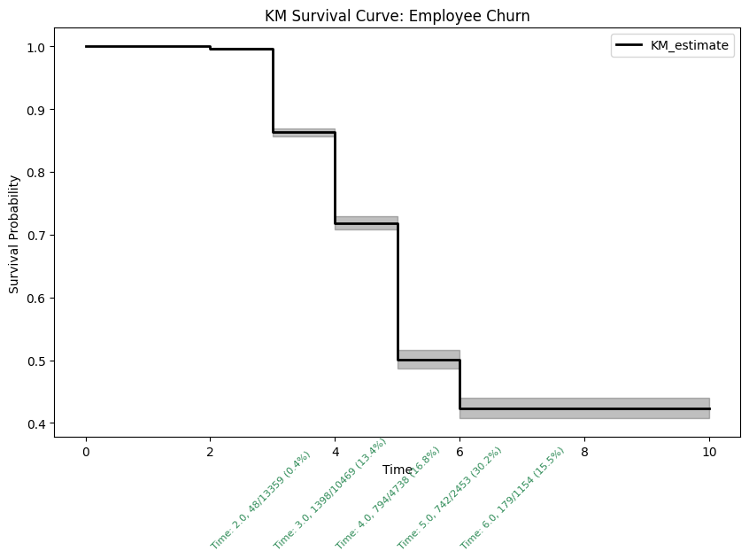

```python
kmf = KaplanMeierFitter()
kmf.fit(durations=df['tenure_years'], event_observed=df['churn'])

plt.figure(figsize=(10,6))
kmf.plot_survival_function(ci_show=True, lw=2, color='black')

event_table = kmf.event_table

for t, n_risk, obs in zip(event_table.index, event_table['at_risk'], event_table['observed']):
    if obs > 0:
        churn_percentage = (obs / n_risk) * 100
        plt.text(t, 0.2, f"Time: {t:.1f}, {int(obs)}/{int(n_risk)} ({churn_percentage:.1f}%) ", rotation=45, fontsize=8, color='seagreen')

plt.title("KM Survival Curve: Employee Churn")
plt.xlabel("Time")
plt.ylabel("Survival Probability")
plt.show()
```

Show Kaplan Meier event table for raw data:

**Conditional Survival:**

The probability of surviving for the given interval, provided the employee had not churned at the start of the interval.

**Cumulative Survival:**

The overall survival probability up to time t. It is a product of the conditional probabilities.

```python
event_table['percent_lost']=event_table['observed']/event_table['at_risk']
event_table['percent_lost']=event_table['percent_lost'].round(2)*100

event_table["conditional_survival"] = 1 - (event_table["observed"] / event_table["at_risk"])
event_table["cumulative_survival"] = event_table["conditional_survival"].cumprod()

event_table = event_table.reset_index()

event_table = event_table[[
    "event_at", "at_risk", "observed", "censored", "removed",
    "conditional_survival","cumulative_survival"
]]

print(event_table)
```

```
   event_at  at_risk  observed  censored  removed  conditional_survival  \
0       0.0    13359         0         0        0              1.000000
1       2.0    13359        48      2842     2890              0.996407
2       3.0    10469      1398      4333     5731              0.866463
3       4.0     4738       794      1491     2285              0.832419
4       5.0     2453       742       557     1299              0.697513
5       6.0     1154       179       444      623              0.844887
6       7.0      531         0       182      182              1.000000
7       8.0      349         0       149      149              1.000000
8      10.0      200         0       200      200              1.000000

   cumulative_survival
0             1.000000
1             0.996407
2             0.863350
3             0.718668
4             0.501281
5             0.423526
6             0.423526
7             0.423526
8             0.423526
```

```python
hazard = event_table['observed'] / event_table['at_risk']

peak_time = hazard.idxmax()
print("Peak churn risk occurs at time:", peak_time)
```

```
Peak churn risk occurs at time: 4
```

The KM median survival time is where the estimated survival probability (adjusted for censoring) has declined to 50%. This is at 6 years, with 95% confidence from 5-6 years.

```python
median_ = kmf.median_survival_time_
median_confidence_interval_ = median_survival_times(kmf.confidence_interval_)
print(median_)
print(median_confidence_interval_)
```

```
6.0
     KM_estimate_lower_0.95  KM_estimate_upper_0.95
0.5                     5.0                     6.0
```

[figure not shown]

The first model I tried was the Cox Proportional Hazards Model, which model hazard rates. A hazard rate is the instantaneous churn risk at time t given that they survived up to time t.

```python
cph = CoxPHFitter()
cph.fit(df, duration_col='tenure_years', event_col='churn')
cph.print_summary(style='ascii')
```

```
<lifelines.CoxPHFitter: fitted with 13359 total observations, 10198 right-censored observations>
             duration col = 'tenure_years'
                event col = 'churn'
      baseline estimation = breslow
   number of observations = 13359
number of events observed = 3161
   partial log-likelihood = -25912.98
         time fit was run = 2025-12-12 23:56:44 UTC

---
                        coef exp(coef)  se(coef)  coef lower 95%  coef upper 95% exp(coef) lower 95% exp(coef) upper 95%
covariate
avg_monthly_hrs         0.00      1.00      0.00            0.00            0.00                1.00                1.00
filed_complaint        -1.28      0.28      0.08           -1.44           -1.11                0.24                0.33
n_projects             -0.21      0.81      0.02           -0.24           -0.18                0.78                0.83
recently_promoted      -1.34      0.26      0.24           -1.81           -0.87                0.16                0.42
department_IT          -0.21      0.81      0.07           -0.36           -0.07                0.70                0.93
department_admin       -0.35      0.70      0.17           -0.69           -0.01                0.50                0.99
department_engineering  0.03      1.03      0.06           -0.09            0.14                0.91                1.15
department_finance     -0.10      0.90      0.08           -0.27            0.06                0.77                1.07
department_management  -0.31      0.73      0.12           -0.55           -0.08                0.58                0.92
department_marketing   -0.14      0.87      0.08           -0.30            0.03                0.74                1.03
department_procurement -0.98      0.38      0.25           -1.47           -0.48                0.23                0.62
department_product     -0.18      0.83      0.08           -0.35           -0.02                0.71                0.98
department_sales       -0.10      0.90      0.05           -0.21            0.00                0.81                1.00
salary_low              1.62      5.04      0.12            1.38            1.86                3.97                6.40
salary_medium           1.13      3.09      0.12            0.89            1.37                2.43                3.93
satisfaction_medium     0.01      1.01      0.05           -0.09            0.11                0.92                1.11
satisfaction_high      -1.11      0.33      0.05           -1.21           -1.01                0.30                0.36

                        cmp to      z      p  -log2(p)
covariate
avg_monthly_hrs           0.00   5.45 <0.005     24.25
filed_complaint           0.00 -15.10 <0.005    168.69
n_projects                0.00 -13.18 <0.005    129.39
recently_promoted         0.00  -5.63 <0.005     25.69
department_IT             0.00  -2.94 <0.005      8.27
department_admin          0.00  -2.01   0.04      4.48
department_engineering    0.00   0.43   0.67      0.58
department_finance        0.00  -1.20   0.23      2.11
department_management     0.00  -2.66   0.01      7.01
department_marketing      0.00  -1.61   0.11      3.21
department_procurement    0.00  -3.85 <0.005     13.03
department_product        0.00  -2.14   0.03      4.95
department_sales          0.00  -1.87   0.06      4.04
salary_low                0.00  13.24 <0.005    130.46
salary_medium             0.00   9.15 <0.005     63.92
satisfaction_medium       0.00   0.21   0.84      0.26
satisfaction_high         0.00 -22.35 <0.005    365.03
---
Concordance = 0.82
Partial AIC = 51859.96
log-likelihood ratio test = 1896.40 on 17 df
-log2(p) of ll-ratio test = inf
```

The coefficients are reported, showing the impact of each covariate on churn hazard. They are interpreted as follows:

e.g., Engineering has coefficient of 0.03. Thus, a one unit increase in the coefficient (being in Engineering dept) means the the baseline hazard will increase by a factor of exp(0.03) about a 3% increase (exp(coef) = 1.03).

exp(coef) = exp(0.03) = hazard of Engineering employees / hazard of non-Engineering employees

The baseline churn hazard rate is shown below, which would read the same way the Kaplan-Meier conditional probabilities would, with a 13% churn hazard risk at year 4, and the largest at year 5, followed by year 6 with 14%.

```python
cph.baseline_hazard_
```

|  | baseline hazard |
| --- | --- |
| 2.0 | 0.002461 |
| 3.0 | 0.088469 |
| 4.0 | 0.130548 |
| 5.0 | 0.266752 |
| 6.0 | 0.140777 |
| 7.0 | 0.000000 |
| 8.0 | 0.000000 |
| 10.0 | 0.000000 |

The peak churn risk is also at 5 years based on the CoxPH model:

```python
baseline_hazard = cph.baseline_hazard_
peak_time = baseline_hazard.idxmax().iloc[0]
print("Peak churn risk occurs at time:", peak_time)
```

```
Peak churn risk occurs at time: 5.0
```

The CPH plot visualized the relative impact of each covariate, showing that low salary would increase the hazard rate and getting a recent promotion, filing a complaint, having high satistfaction and being the procurement dept would decrease the hazard rate:

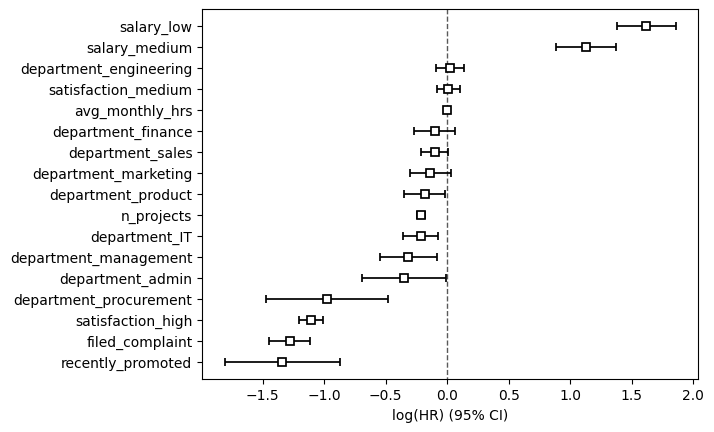

```python
cph.plot()
```

These CPH partial effects plots show the impact of the covariates in a different way, showing survival curves for each of the paired binary variables against each other to show for example the survival curve of those that filed a complaint vs. those that didn't. The findings are the same as from the plot above and the exp(coef)'s, however you can see the differences in impact at times t.

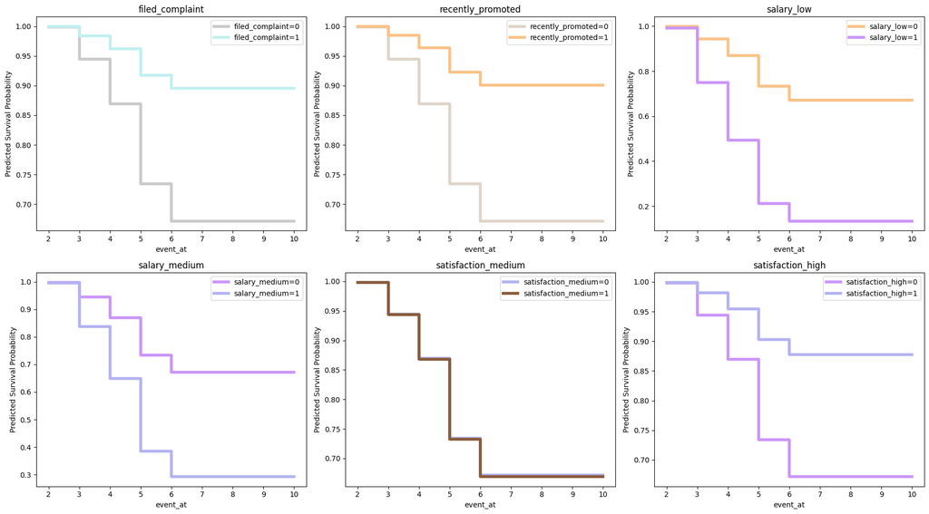

```python
covariates = ['filed_complaint', 'recently_promoted', 'salary_low', 'salary_medium', 'satisfaction_medium', 'satisfaction_high']
colors_list = [custom_palette[10:12], custom_palette[2:8], custom_palette[3:9],
               custom_palette[4:10], custom_palette[5:11], custom_palette[4:7]]

fig, axes = plt.subplots(2, 3, figsize=(18,10))

axes = axes.flatten()

for i, cov in enumerate(covariates):
    ax = axes[i]
    cph.plot_partial_effects_on_outcome(
        cov,
        [0, 1],
        plot_baseline=False,
        lw=4,
        color=colors_list[i],
        ax=ax
    )
    ax.set_xlabel("event_at")
    ax.set_ylabel("Predicted Survival Probability")
    ax.set_title(cov)

plt.tight_layout()
plt.show()
```

NOTE: THIS COX PH MODEL DID NOT END UP BEING USABLE. AFTER EXPLORING THE MODEL I TESTED THE PH ASSUMPTION, WHICH FAILED, RENDING THE ANALYIS UNSTABLE/UNRELIABLE:

Seven variables fail the PH assumption test (cleared warnings below due to length), making adjustments and interpretation unrealistic. I made initial attempts to solve for this but they were unsuccessful (transformation to tenure_years, checking VIF, etc.) Therefore the analysis above is not usable.

```python
# cph.check_assumptions(df, p_value_threshold=0.05, show_plots=True)
```

I am going to switch to AFT/parametric models instead of CoxPH:

[figure not shown]

AFT models, which are parametric (have parameters to fit to) measure the time acceleration impact of covariates vs. CoxPH calculated hazard rates/ratios.

[figure not shown]

I first explore baseline models, which model the baseline without covariates:

The models are compared to the Kaplan-Meier curve to have the comparison to the actual data.

Plot baseline model fit:

Some models are easier to rule out than others, and when comparing I will rely on AIC in a raw table further below:

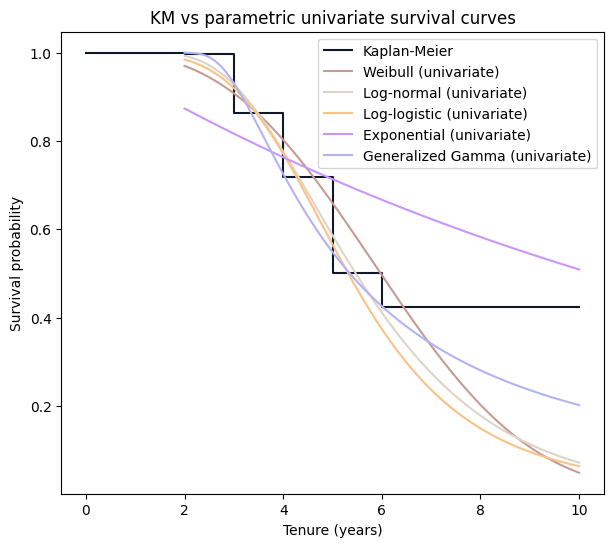

```python
kmf = KaplanMeierFitter()
T = df['tenure_years']
E = df['churn']
kmf.fit(T, event_observed=E, label="Kaplan-Meier")

wb = WeibullFitter().fit(T, event_observed=E, label="Weibull")
lnf = LogNormalFitter().fit(T, event_observed=E, label="Log-normal")
llf = LogLogisticFitter().fit(T, event_observed=E, label="Log-logistic")
exp = ExponentialFitter().fit(T, event_observed=E, label="Exponential")
gg = GeneralizedGammaFitter().fit(T, event_observed=E, label="Generalized Gamma")

t_grid = np.linspace(T.min(), T.max(), 200)

fig, ax = plt.subplots(figsize=(7, 6))

kmf.plot_survival_function(ax=ax, ci_show=False, color=custom_palette[12])

models = [
    (wb, "Weibull (univariate)", 1),
    (lnf, "Log-normal (univariate)", 2),
    (llf, "Log-logistic (univariate)", 3),
    (exp, "Exponential (univariate)", 4),
    (gg, "Generalized Gamma (univariate)", 5)
]

for model, label, color_idx in models:
    ax.plot(t_grid, model.survival_function_at_times(t_grid).values.flatten(),
            label=label, color=custom_palette[color_idx])

ax.set_xlabel("Tenure (years)")
ax.set_ylabel("Survival probability")
ax.set_title("KM vs parametric univariate survival curves")
ax.legend()
plt.show()
```

[figure not shown]

I want to measure the impact of the covariates in the data so I will also model the AFT models, which are used when the PH assumption is violated. Instead of hazard ratios it models how covariates accelerate the time to the event and is best at predicting the time to event.

Plot model fit:

Again this is good to see the fit visually, however I will rely on AIC in a further table.

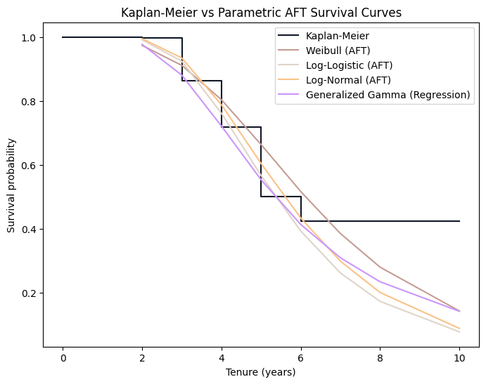

```python
T = df['tenure_years']
E = df['churn']

kmf = KaplanMeierFitter()
kmf.fit(T, event_observed=E, label="Kaplan-Meier")

aft_models = {
    "Weibull (AFT)": WeibullAFTFitter(),
    "Log-Logistic (AFT)": LogLogisticAFTFitter(),
    "Log-Normal (AFT)": LogNormalAFTFitter()
}

gamma_model = GeneralizedGammaRegressionFitter(penalizer=0.5)
gamma_model._scipy_fit_method = "SLSQP"

for name, model in aft_models.items():
    model.fit(df, duration_col='tenure_years', event_col='churn')

gamma_model.fit(df, duration_col='tenure_years', event_col='churn')

t_grid = np.linspace(T.min(), T.max(), 200)

fig, ax = plt.subplots(figsize=(8, 6))

kmf.plot_survival_function(ax=ax, ci_show=False, color=custom_palette[12])

for i, (name, model) in enumerate(aft_models.items()):
    surv_df = model.predict_survival_function(df)
    surv_mean = np.interp(t_grid, surv_df.index.values, surv_df.mean(axis=1))
    ax.plot(t_grid, surv_mean, label=name, color=custom_palette[i+1])

gamma_surv_df = gamma_model.predict_survival_function(df)
gamma_surv_mean = np.interp(t_grid, gamma_surv_df.index.values, gamma_surv_df.mean(axis=1))
ax.plot(t_grid, gamma_surv_mean, label="Generalized Gamma (Regression)",  color=custom_palette[4])

ax.set_xlabel("Tenure (years)")
ax.set_ylabel("Survival probability")
ax.set_title("Kaplan-Meier vs Parametric AFT Survival Curves")
ax.legend()
plt.show()
```

[figure not shown]

I evaluate the model family by selecting the one with the lowest AIC, which is the LogLogistic AFT model:

```python
from lifelines import (
    WeibullFitter,
    LogNormalFitter,
    LogLogisticFitter,
    ExponentialFitter,
    GeneralizedGammaFitter,
    WeibullAFTFitter,
    LogNormalAFTFitter,
    LogLogisticAFTFitter,
    GeneralizedGammaRegressionFitter
)

T = df['tenure_years']
E = df['churn']

models_univariate = {
    "Weibull_uni": WeibullFitter(),
    "LogNormal_uni": LogNormalFitter(),
    "LogLogistic_uni": LogLogisticFitter(),
    "Exponential_uni": ExponentialFitter(),
    "Gamma_uni": GeneralizedGammaFitter()
}

aic_univariate = {}

print("\n====== UNIVARIATE BASELINE MODELS ======")
for name, model in models_univariate.items():
    model.fit(T, event_observed=E)
    aic_univariate[name] = model.AIC_
    print(f"{name:18s} | AIC = {model.AIC_:10.3f}   LogLik = {model.log_likelihood_:10.3f}")

models_aft = {
    "Weibull_AFT": WeibullAFTFitter(),
    "LogNormal_AFT": LogNormalAFTFitter(),
    "LogLogistic_AFT": LogLogisticAFTFitter(),
    "Gamma_AFT": GeneralizedGammaRegressionFitter(penalizer=0.5)
}

# Gamma regression required SLSQP in order to converge
models_aft["Gamma_AFT"]._scipy_fit_method = "SLSQP"

aic_aft = {}

print("\n====== AFT REGRESSION MODELS (WITH COVARIATES) ======")
for name, model in models_aft.items():
    model.fit(df, duration_col="tenure_years", event_col="churn")
    aic_aft[name] = model.AIC_
    print(f"{name:18s} | AIC = {model.AIC_:10.3f}   LogLik = {model.log_likelihood_:10.3f}")

best_uni = min(aic_univariate, key=aic_univariate.get)
best_aft = min(aic_aft, key=aic_aft.get)

print("\n====== MODEL SELECTION SUMMARY ======")
print(f"Best Univariate Baseline Model:  {best_uni}  (AIC = {aic_univariate[best_uni]:.2f})")
print(f"Best AFT Regression Model:      {best_aft}  (AIC = {aic_aft[best_aft]:.2f})")
```

```
====== UNIVARIATE BASELINE MODELS ======
Weibull_uni        | AIC =  18757.579   LogLik =  -9376.790
LogNormal_uni      | AIC =  17209.244   LogLik =  -8602.622
LogLogistic_uni    | AIC =  17546.613   LogLik =  -8771.306
Exponential_uni    | AIC =  23363.378   LogLik = -11680.689
Gamma_uni          | AIC =  16199.551   LogLik =  -8096.776

====== AFT REGRESSION MODELS (WITH COVARIATES) ======
Weibull_AFT        | AIC =  16684.557   LogLik =  -8323.279
LogNormal_AFT      | AIC =  14676.389   LogLik =  -7319.195
LogLogistic_AFT    | AIC =  14583.298   LogLik =  -7272.649
Gamma_AFT          | AIC =  17597.853   LogLik =  -8747.926

====== MODEL SELECTION SUMMARY ======
Best Univariate Baseline Model:  Gamma_uni  (AIC = 16199.55)
Best AFT Regression Model:      LogLogistic_AFT  (AIC = 14583.30)
```

Note: I also tried the PiecewiseExponentialRegression Fitter which sounded like an appropriate model given the natural breakpoints of the 10 years of tenure, however, even after adjustments and penalties, it had significant warnings and was unstable, keeping the Log-Logistic as the best model to use.

[figure not shown]

I tune the hyperparameters optimizing to the C-index. The C-index indicates how well the model performs at prediction by using k-fold cross-validation and providing a score which can be compared between models. I prioritized C-index over AIC here, because I already evaluated that the AIC did well as a model family:

```python
warnings.filterwarnings("ignore", category=exceptions.StatisticalWarning)
# Supressing lengthy warning that came from 0.5 penalizer models

penalizers = [0.0, 1e-3, 1e-2, 5e-2, 1e-1, 5e-1]
l1_ratios = [0.0, 0.5, 1.0]

results = {}
kf = KFold(n_splits=5, shuffle=True, random_state=42)

for penalizer in penalizers:
    for l1_ratio in l1_ratios:
        aft_cv = LogLogisticAFTFitter(penalizer=penalizer, l1_ratio=l1_ratio)
        cv_scores = []
        for train_idx, val_idx in kf.split(df):
            train = df.iloc[train_idx]
            val = df.iloc[val_idx]
            aft_cv.fit(train, 'tenure_years', 'churn')
            cv_scores.append(aft_cv.concordance_index_)
        cv_concordance = np.mean(cv_scores)

        aft_full = LogLogisticAFTFitter(penalizer=penalizer, l1_ratio=l1_ratio)
        aft_full.fit(df, 'tenure_years', 'churn')
        aic = aft_full.AIC_

        results[(penalizer, l1_ratio)] = {'concordance': cv_concordance, 'AIC': aic}
        print(f"penalizer={penalizer}, l1_ratio={l1_ratio}: C={cv_concordance:.3f}, AIC={aic:.1f}")
```

```
penalizer=0.0, l1_ratio=0.0: C=0.834, AIC=14583.3
penalizer=0.0, l1_ratio=0.5: C=0.834, AIC=14583.3
penalizer=0.0, l1_ratio=1.0: C=0.834, AIC=14583.3
penalizer=0.001, l1_ratio=0.0: C=0.834, AIC=14626.5
penalizer=0.001, l1_ratio=0.5: C=0.834, AIC=14642.0
penalizer=0.001, l1_ratio=1.0: C=0.834, AIC=14657.4
penalizer=0.01, l1_ratio=0.0: C=0.834, AIC=15005.2
penalizer=0.01, l1_ratio=0.5: C=0.835, AIC=15157.8
penalizer=0.01, l1_ratio=1.0: C=0.836, AIC=15300.9
penalizer=0.05, l1_ratio=0.0: C=0.834, AIC=16487.0
penalizer=0.05, l1_ratio=0.5: C=0.835, AIC=17207.4
penalizer=0.05, l1_ratio=1.0: C=0.832, AIC=17765.7
penalizer=0.1, l1_ratio=0.0: C=0.831, AIC=17936.6
penalizer=0.1, l1_ratio=0.5: C=0.832, AIC=19277.3
penalizer=0.1, l1_ratio=1.0: C=0.833, AIC=20327.6
penalizer=0.5, l1_ratio=0.0: C=0.804, AIC=22112.1
penalizer=0.5, l1_ratio=0.5: C=0.698, AIC=24133.3
penalizer=0.5, l1_ratio=1.0: C=0.714, AIC=27222.2
```

The concordance score (c-index) evaluates the rankings (rankings as in: employee A has a shorter survival time than employee B) as opposed to predicting accurate survival times.

[figure not shown]

This shows the tuned model output (with the penalty), which we have seen previously above. It has a concordance of 0.84, log-likelihood of -7631, and AIC of 15300.

```python
aft = LogLogisticAFTFitter(penalizer=0.01, l1_ratio=1)
aft.fit(df, 'tenure_years', 'churn')

aft.print_summary(columns=['coef', 'exp(coef)'])
```

| model | lifelines.LogLogisticAFTFitter |
| --- | --- |
| duration col | 'tenure_years' |
| event col | 'churn' |
| penalizer | 0.01 |
| number of observations | 13359 |
| number of events observed | 3161 |
| log-likelihood | -7631.43 |
| time fit was run | 2025-12-13 00:04:20 UTC |

|  |  | coef | exp(coef) |
| --- | --- | --- | --- |
| alpha_ | avg_monthly_hrs | -0.00 | 1.00 |
|  | department_IT | 0.02 | 1.02 |
|  | department_admin | 0.02 | 1.02 |
|  | department_engineering | -0.02 | 0.98 |
|  | department_finance | 0.00 | 1.00 |
|  | department_management | 0.18 | 1.20 |
|  | department_marketing | 0.01 | 1.01 |
|  | department_procurement | 0.15 | 1.16 |
|  | department_product | 0.01 | 1.01 |
|  | department_sales | 0.01 | 1.01 |
|  | filed_complaint | 0.32 | 1.38 |
|  | n_projects | 0.07 | 1.07 |
|  | recently_promoted | 0.39 | 1.47 |
|  | salary_low | -0.38 | 0.69 |
|  | salary_medium | -0.27 | 0.76 |
|  | satisfaction_high | 0.35 | 1.43 |
|  | satisfaction_medium | -0.01 | 0.99 |
|  | Intercept | 1.57 | 4.80 |
| beta_ | Intercept | 1.73 | 5.66 |

| Concordance | 0.84 |
| --- | --- |
| AIC | 15300.87 |
| log-likelihood ratio test | 2279.75 on 17 df |
| -log2(p) of ll-ratio test | inf |

However, although this conveys the rankings, I need to refit model with no penalty to get also the non-biased time ratios:

Removed coefficients that are ~0 to create a subset of variables to input into unbiased model:

```python
alphas = aft.summary.loc['alpha_']['coef']
selected_vars = [var for var in alphas[abs(alphas) >= 0.03].index.tolist() if var != 'Intercept']
print(f"Selected significant variables: {selected_vars}")
```

```
Selected significant variables: ['department_management', 'department_procurement', 'filed_complaint', 'n_projects', 'recently_promoted', 'salary_low', 'salary_medium', 'satisfaction_high']
```

Refit model just with selected variables:

```python
aft_unbiased = LogLogisticAFTFitter(penalizer=0.0)

columns_for_fit = selected_vars + ['tenure_years', 'churn']
aft_unbiased.fit(df[columns_for_fit], 'tenure_years', 'churn')

aft_unbiased.print_summary(columns=['coef', 'exp(coef)', 'se(coef)', 'p'])
```

| model | lifelines.LogLogisticAFTFitter |
| --- | --- |
| duration col | 'tenure_years' |
| event col | 'churn' |
| number of observations | 13359 |
| number of events observed | 3161 |
| log-likelihood | -7299.94 |
| time fit was run | 2025-12-13 00:04:23 UTC |

|  |  | coef | exp(coef) | se(coef) | p |
| --- | --- | --- | --- | --- | --- |
| alpha_ | department_management | 0.17 | 1.19 | 0.03 | <0.005 |
|  | department_procurement | 0.18 | 1.20 | 0.05 | <0.005 |
|  | filed_complaint | 0.34 | 1.40 | 0.02 | <0.005 |
|  | n_projects | 0.06 | 1.06 | 0.00 | <0.005 |
|  | recently_promoted | 0.42 | 1.52 | 0.05 | <0.005 |
|  | salary_low | -0.47 | 0.62 | 0.03 | <0.005 |
|  | salary_medium | -0.37 | 0.69 | 0.03 | <0.005 |
|  | satisfaction_high | 0.36 | 1.43 | 0.01 | <0.005 |
|  | Intercept | 1.59 | 4.93 | 0.03 | <0.005 |
| beta_ | Intercept | 1.75 | 5.78 | 0.01 | <0.005 |

| Concordance | 0.84 |
| --- | --- |
| AIC | 14619.89 |
| log-likelihood ratio test | 2942.72 on 8 df |
| -log2(p) of ll-ratio test | inf |

Unbiased covariate impact and significance:

AFT beta's (exp(coef)) are Time Ratios / acceleration factors. They multiply the time to event.

great than 1 → survival time increases as 𝑋𝑖 increases

less than 1 → survival time decreases as 𝑋𝑖 increases

```python
aft_unbiased_summary = aft_unbiased.summary.loc['alpha_']

p_col = 'p' if 'p' in aft_unbiased_summary.columns else 'p-value'
summary_subset = aft_unbiased_summary[['exp(coef)', p_col]].rename(columns={p_col: 'p'})

summary_subset['significant'] = summary_subset['p'] < 0.05

increases = summary_subset[summary_subset['exp(coef)'] > 1].sort_values(by='exp(coef)', ascending=False)
decreases = summary_subset[summary_subset['exp(coef)'] <= 1].sort_values(by='exp(coef)', ascending=True)

print("=== Time Ratios (Highest to Lowest) ===")
print("When covariate increases by 1, the expected survival duration changes by a factor of ____ :\n")

print("--- >1: Increases Survival ---")
print(increases)

print("\n--- <1: Decreases Survival ---")
print(decreases)
```

```
=== Time Ratios (Highest to Lowest) ===
When covariate increases by 1, the expected survival duration changes by a factor of ____ :

--- >1: Increases Survival ---
                        exp(coef)              p  significant
covariate
Intercept                4.926868   0.000000e+00         True
recently_promoted        1.523309   1.767734e-14         True
satisfaction_high        1.427999   0.000000e+00         True
filed_complaint          1.403079   3.618804e-69         True
department_procurement   1.202124   6.650798e-04         True
department_management    1.188153   1.350199e-10         True
n_projects               1.064590  1.516767e-127         True

--- <1: Decreases Survival ---
               exp(coef)             p  significant
covariate
salary_low      0.622253  2.333843e-56         True
salary_medium   0.691152  2.339357e-34         True
```

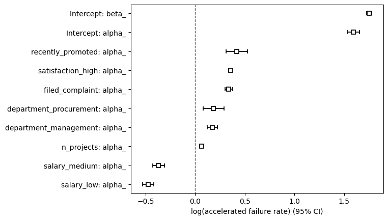

```python
aft_unbiased.plot()
```

Survival curves visualize the differences in survival between the categorical covariates with the refit/unbiased model:

```
Binary covariates to plot: ['department_management', 'department_procurement', 'filed_complaint', 'recently_promoted', 'salary_low', 'salary_medium', 'satisfaction_high']
```

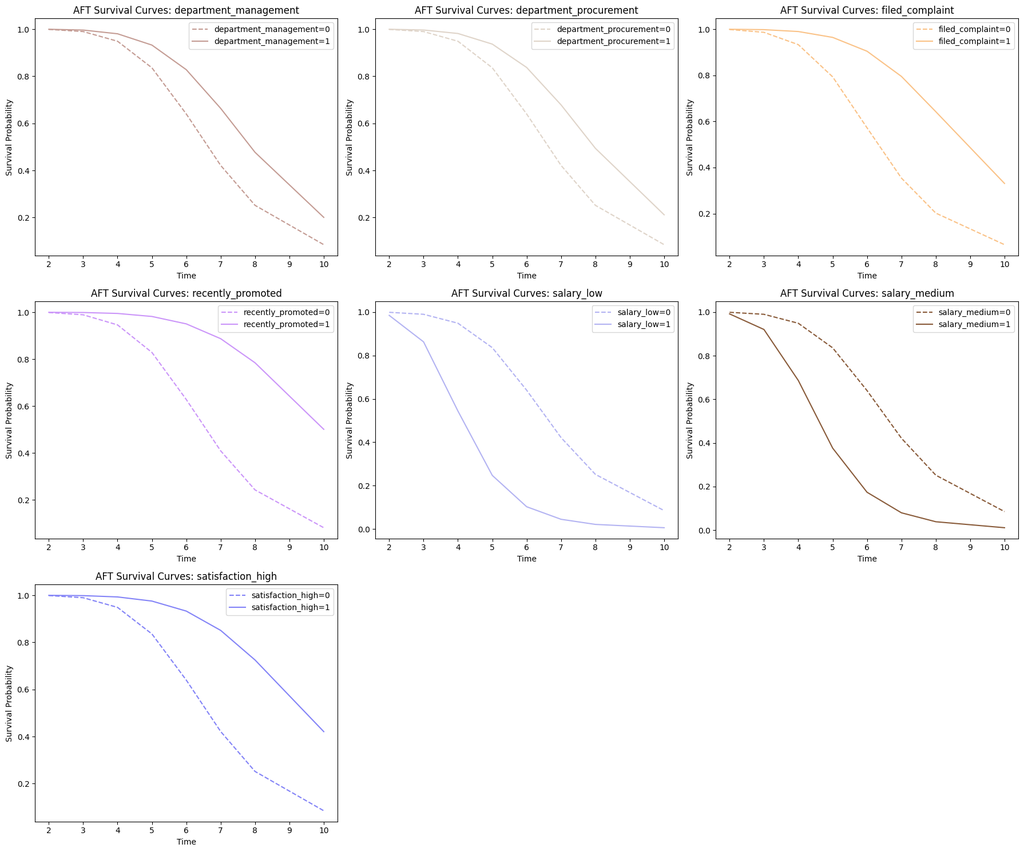

```python
binary_covs = [
    c for c in selected_vars
    if ((df[c].dropna().isin([0, 1]).all()) or (df[c].dtype == 'bool'))
]

print("Binary covariates to plot:", binary_covs)

base_profile_data = {}
for col in selected_vars:
    if df[col].dtype in ['int64', 'float64']:
        base_profile_data[col] = df[col].mean()
    elif df[col].dtype == 'bool':
        base_profile_data[col] = 0
    else:
        base_profile_data[col] = df[col].mode()[0]

base_profile_df = pd.DataFrame([base_profile_data])
base_profile_df = base_profile_df[selected_vars]

n = len(binary_covs)
cols = 3
rows = math.ceil(n / cols)

fig, axes = plt.subplots(rows, cols, figsize=(18, 5 * rows))
axes = axes.flatten()

for i, cov in enumerate(binary_covs):
    ax = axes[i]

    profile0 = base_profile_df.copy()
    profile1 = base_profile_df.copy()
    profile0[cov] = 0.0
    profile1[cov] = 1.0

    sf0 = aft_unbiased.predict_survival_function(profile0)
    sf1 = aft_unbiased.predict_survival_function(profile1)

    sf0.columns = [f"{cov}=0"]
    sf1.columns = [f"{cov}=1"]

    ax.plot(sf0.index, sf0.iloc[:, 0],
            label=f"{cov}=0", color=custom_palette[i+1], linestyle="--")
    ax.plot(sf1.index, sf1.iloc[:, 0],
            label=f"{cov}=1", color=custom_palette[i+1])

    ax.set_title(f"AFT Survival Curves: {cov}")
    ax.set_xlabel("Time")
    ax.set_ylabel("Survival Probability")
    ax.legend()

for j in range(i+1, len(axes)):
    fig.delaxes(axes[j])

plt.tight_layout()
plt.show()
```

Median time to churn, based on the unbiased aft model:

```python
X = df[selected_vars]

censored = df[~df['churn'].astype(bool)]
uncensored = df[df['churn'].astype(bool)]

X_cens = censored[selected_vars]
X_uncens = uncensored[selected_vars]

cens_medians = aft_unbiased.predict_median(X_cens)
uncens_medians = aft_unbiased.predict_median(X_uncens)

cens_group_median = cens_medians.mean()
uncens_group_median = uncens_medians.mean()

print(f"Censored median total time: {cens_group_median:.2f} years")
print(f"Uncensored median total time: {uncens_group_median:.2f} years")
print(f"Full group median total time: {aft_unbiased.predict_median(X).mean():.2f} years")
```

```
Censored median total time: 5.91 years
Uncensored median total time: 4.76 years
Full group median total time: 5.64 years
```

Predicted remaining survival time for censored:

Use "conditional_after" to make it so that the predictions are the remaining time from the censoring point forward (not total time of survival):

```python
censored_subjects_last_obs = censored['tenure_years']

censored_survival_function = aft_unbiased.predict_survival_function(censored, conditional_after=censored_subjects_last_obs)

group_survival_function = censored_survival_function.mean(axis=1)

group_median_remaining = group_survival_function[group_survival_function <= 0.5].index[0]
print(f"Group median remaining time: {group_median_remaining:.2f} years")
```

```
Group median remaining time: 3.00 years
```

Predicted total survival functions for censored, uncensored, and full group:

```python
cens_sf = aft_unbiased.predict_survival_function(X_cens)
uncens_sf = aft_unbiased.predict_survival_function(X_uncens)
full_sf = aft_unbiased.predict_survival_function(X)

cens_group_sf = cens_sf.mean(axis=1)
uncens_group_sf = uncens_sf.mean(axis=1)
full_group_sf = full_sf.mean(axis=1)

comparison_table = pd.DataFrame({
    'Censored_only': cens_group_sf,
    'Uncensored_only': uncens_group_sf,
    'Full_group': full_group_sf
})

print(comparison_table.head(10))
```

```
      Censored_only  Uncensored_only  Full_group
2.0        0.993519         0.984099    0.991290
3.0        0.941740         0.869852    0.924730
4.0        0.800219         0.634083    0.760908
5.0        0.611679         0.410199    0.564005
6.0        0.432441         0.247598    0.388704
7.0        0.292695         0.143277    0.257340
8.0        0.195930         0.082330    0.169050
10.0       0.089306         0.028911    0.075016
```

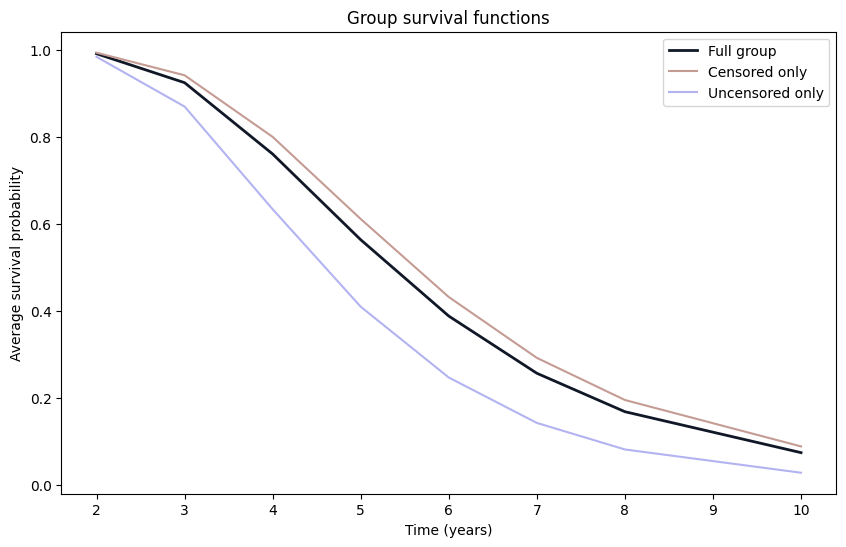

```python
fig, ax = plt.subplots(figsize=(10, 6))
full_group_sf.plot(ax=ax, label="Full group", color=custom_palette[12], linewidth=2)
cens_group_sf.plot(ax=ax, label="Censored only", color=custom_palette[1])
uncens_group_sf.plot(ax=ax, label="Uncensored only", color=custom_palette[5])
ax.set_xlabel("Time (years)")
ax.set_ylabel("Average survival probability")
ax.set_title("Group survival functions")
ax.legend()
plt.show()
```

# Prediction Accuracy

The goal of the project was covariate ranking / identifying covariates with highest impact. If the goal were prediction (to predict the most accurate survival times for individuals), I would have different evaluation metrics.

Since it does not perform well on calibration, it should not be used reliably for the time-to-churn estimates above, only for the covariate rankings. Calibration compares survival probabilities (predicted vs. observed) at time t:

The model appears mostly conservative (under curve for most t's): Curve under diagonal: overpredicts risk (conservative). Curve over diagonal: underpredicts risk

Example for t10 below:

ICI (Integrated Calibration Index) = 0.066: , mean |predicted S(t0) - observed S(t0)| across the curve. "On average, the model’s predicted survival probability is ~6.6 percentage points off from observed"

E50 (50th percentile of absolute diff between predicted and observed probabilities)= 0.015: . Close to 0. This mean half of predictions <= 1.5% of observed. "For 50% of individuals, the model’s predicted survival probability is within 1.5 percentage points of the observed survival."

Lack of Guidelines:

Lower #s are better for the metrics that are output (ICI and E50), however there aren't hard cutoffs/guidelines: "Given that there is no reference value for what constitutes an acceptable value of ICI, E50, or E90, these metrics will have limited utility when attention is restricted to a single model. However, these metrics can serve an important function when developing a prediction model. When the prediction method includes tuning parameters (as do random survival forests), the value of these metrics can be evaluated at different values of the tuning parameter and the value that optimizes calibration can be selected" (source: https://onlinelibrary.wiley.com/doi/10.1002/sim.8570)

Even without hard guidelines, since I can see many of the ICI's are >0.05 that means they are more than 5 percentage points off, and many at or above 0.1 (10 percentage points) that is not great, as with prediction an ideal of less than 5% off is common.

Again, this model does not perform well on prediction, therefore it should only for the covariate rankings (not the time-to-churn estimates). If the goal of the project were prediction, I would build a new model.

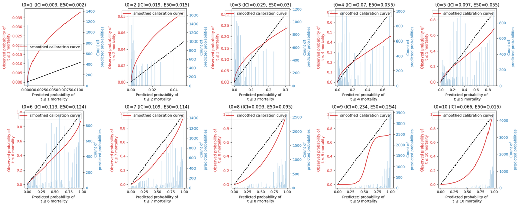

```
t0=1: ICI=0.003, E50=0.002
t0=2: ICI=0.019, E50=0.015
t0=3: ICI=0.029, E50=0.03
t0=4: ICI=0.07, E50=0.035
t0=5: ICI=0.097, E50=0.055
t0=6: ICI=0.113, E50=0.124
t0=7: ICI=0.109, E50=0.114
t0=8: ICI=0.093, E50=0.095
t0=9: ICI=0.234, E50=0.254
t0=10: ICI=0.066, E50=0.015
```

```python
metrics = {}
fig, axes = plt.subplots(2, 5, figsize=(20, 8))
axes = axes.ravel()

# Hide initial printed output
f = io.StringIO()

for i, t0 in enumerate(range(1, 11)):
    with contextlib.redirect_stdout(f), contextlib.redirect_stderr(f):
        ax_plot, ici, e50 = survival_probability_calibration(
            aft_unbiased,
            df[selected_vars + ['tenure_years', 'churn']],
            t0=t0,
            ax=axes[i]
        )

    metrics[t0] = {'ICI': round(ici, 3), 'E50': round(e50, 3)}
    axes[i].set_title(
        f't0={t0} (ICI={metrics[t0]["ICI"]}, E50={metrics[t0]["E50"]})'
    )

plt.tight_layout()
plt.show()

for t0, vals in metrics.items():
    print(f"t0={t0}: ICI={vals['ICI']}, E50={vals['E50']}")
```

[figure not shown]

The major factors that ended up impacting employee time-to-churn (in order) are:

1. Being recently promoted (increases)
2. Having high satisfaction (increases)
3. Filing a complaint (increases)
4. Having a low salary (decreases)
5. Being in management dept (increases)
6. Being in procurement dept (increases)
7. Number of projects (increases)

Interestingly, the following factor was not important:

1. Monthly hours

It is also interesting that the number of projects *increases* time-to-churn, which may be related to "engagement" with the role, which has been known to increase employee satisfaction.

It is also notable that filing a complaint *increases* time-to-churn, which may be to positive action taken by HR after the incident, encouraging them to stay.

The rest of the results track with common sense logic, where getting a promotion and a high salary, and having high satisfaction would lead one to stay in a role because they are happy with those important factors.

[figure not shown]

In order to reduce employee churn, I recommend to the company leaders that they prioritize the following:

- Promotions when appropriate
- Industry-competitive salaries (and raises)
- Surveys to understand satisfaction drivers
- Have check-ins to offer more projects to employees if they are interested
- Survey questions/analysis also specifically for mgmt. & procurement
- Additionally, investigate cases where complaints were filed to understand pattern of it improving retention, as complaints would obviously not be a goal